# Image Processing Assignment 2

submitted to: eng Aly osama

```python
import cv2
import numpy as np
import matplotlib.pyplot as plt
%matplotlib inline
```

# submitted by

##### احمد إيهاب أحمد محمد عيسى 1300072

#### ahmedehabessa@hotmail.com

# Question 1

Use the dilation operation on this image with two different structuring elements (square and circule )

This size of structuring element 19X19

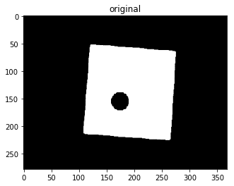

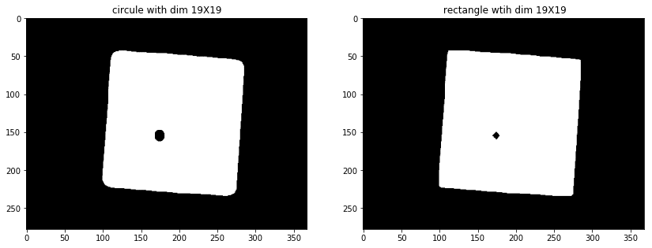

```python
img2 = cv2.imread("Square-circle.png",cv2.IMREAD_GRAYSCALE)

plt.title('original')
plt.imshow(img2,cmap='gray')
plt.show()


dilation_with_circule = cv2.dilate(img2 , cv2.getStructuringElement(cv2.MORPH_ELLIPSE,(19,19)) , iterations = 1)

dilation_with_rectangle = cv2.dilate(img2 , cv2.getStructuringElement(cv2.MORPH_RECT,(19,19)) , iterations = 1)


plt.figure(figsize=(14,18))
plt.subplot(121) , plt.title('circule with dim 19X19') , plt.imshow(dilation_with_circule,cmap='gray')
plt.subplot(122) , plt.title(' rectangle wtih dim 19X19') , plt.imshow(dilation_with_rectangle,cmap='gray')
plt.show()
```

# Question 2

###### dilation can be used to fill in small spurious holes (‘pepper noise’) in images.

[figure not shown]

[figure not shown]

```python
img3=cv2.imread("Cameraman.png" , cv2.IMREAD_GRAYSCALE)

plt.figure(figsize=(12,12))
plt.title('original')
plt.imshow(img3,cmap='gray')
plt.show()

cameraman_denoised= cv2.dilate(img3 , cv2.getStructuringElement(cv2.MORPH_ELLIPSE,(3,3)) , iterations = 1)

plt.figure(figsize=(12,12))
plt.title('cameraman-denoised') , plt.imshow(cameraman_denoised,cmap='gray')
plt.show()
```

# Question 3

##### Edge detection can be accomplished using dilation in conjunction erosion by subtraction

[figure not shown]

[figure not shown]

```python
img4 = cv2.imread( "lady.png" , cv2.IMREAD_GRAYSCALE)

plt.figure(figsize=(10,10))
plt.title('original')
plt.imshow(img4,cmap='gray')
plt.show()

dilation = cv2.dilate(img4 ,cv2.getStructuringElement(cv2.MORPH_RECT , (3,3)) , iterations = 1 )

erosion = cv2.erode (dilation , cv2.getStructuringElement(cv2.MORPH_RECT , (3,3)) , iterations = 1)
lady_edge = np.subtract(dilation , erosion)

plt.figure(figsize=(10,10))
plt.title('lady-edge')
plt.imshow(lady_edge,cmap='gray')
plt.show()
```

# Question 4

## A)

##### Apply the erosion technique to ‘circle-square.png’ with two diffrent kernels circule and rectangle

## B)

##### Do a thresholding of circules image and then use the erosion operation to display the circles distinctly in the image

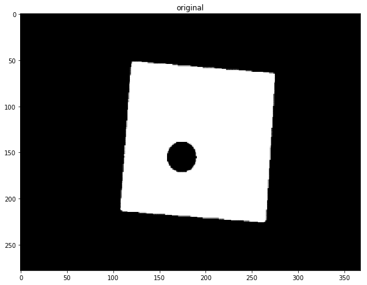

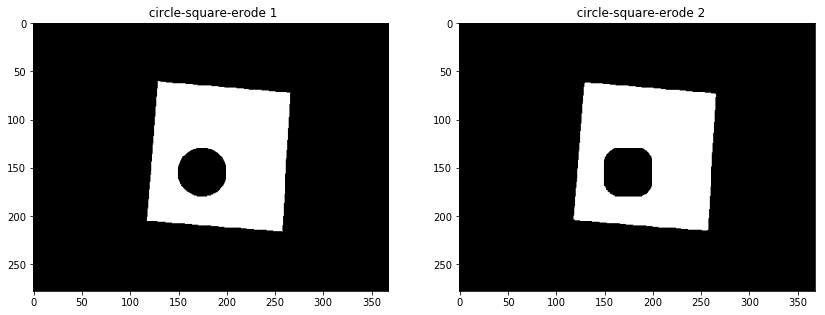

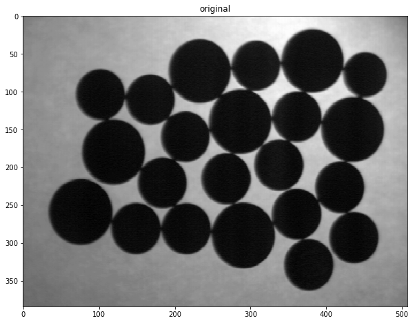

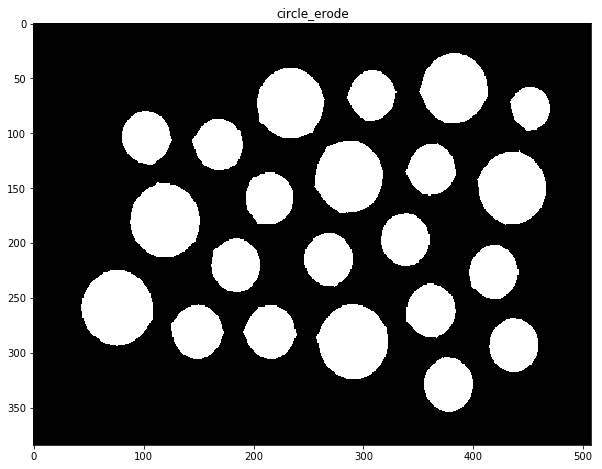

```python
img5 = cv2.imread("Square-circle.png" ,cv2.IMREAD_GRAYSCALE)

plt.figure(figsize=(10,10))
plt.title('original')
plt.imshow(img5,cmap='gray')
plt.show()



erosion_with_circule = cv2.erode(img2 , cv2.getStructuringElement(cv2.MORPH_ELLIPSE,(19,19)) , iterations = 1)

erosion_with_rectangle = cv2.erode(img2 , cv2.getStructuringElement(cv2.MORPH_RECT,(19,19)) , iterations = 1)


plt.figure(figsize=(14,18))
plt.subplot(121) , plt.title(' circle-square-erode 1') , plt.imshow(erosion_with_circule,cmap='gray')
plt.subplot(122) , plt.title('  circle-square-erode 2') , plt.imshow(erosion_with_rectangle,cmap='gray')
plt.show()


img6 = cv2.imread("Circle.png" ,cv2.IMREAD_GRAYSCALE)
plt.figure(figsize=(10,10))
plt.title('original')
plt.imshow(img6,cmap='gray')
plt.show()



ret,thresh1 = cv2.threshold(img6,90,255, cv2.THRESH_BINARY)
circle_erode = cv2.erode(thresh1-255 , cv2.getStructuringElement(cv2.MORPH_ELLIPSE,(19,19)) , iterations = 1)


plt.figure(figsize=(10,10)) , plt.title('circle_erode') , plt.imshow(circle_erode , cmap='gray')
plt.show()
```

# Question 6

##### Using the same image in the problem 2 (cameraman.png) reduce the salt noise in the image using the erosion technique

[figure not shown]

[figure not shown]

```python
#img3=cv2.imread("Cameraman.png" , cv2.IMREAD_GRAYSCALE)

plt.figure(figsize=(12,12))
plt.title('original')
plt.imshow(img3,cmap='gray')
plt.show()

cameraman_denoised= cv2.erode(img3 , cv2.getStructuringElement(cv2.MORPH_ELLIPSE,(3,3)) , iterations = 1)

plt.figure(figsize=(12,12))
plt.title('cameraman-denoised') , plt.imshow(cameraman_denoised,cmap='gray')
plt.show()
```

# Question 7

## A)

##### separating out various objects from the images using opeing and closing and tophat operations

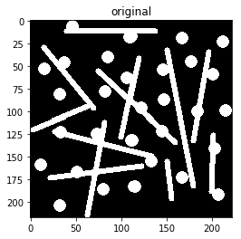

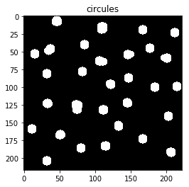

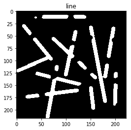

```python
img7 = cv2.imread("Circle_and_Lines.png" , cv2.IMREAD_GRAYSCALE)

#plt.figure(figsize=(7,7))
plt.title('original')
plt.imshow(img7,cmap='gray')
plt.show()

circules= cv2.morphologyEx(img7 , cv2.MORPH_OPEN,cv2.getStructuringElement(cv2.MORPH_ELLIPSE ,(11,11)))


#plt.figure(figsize=(7,7))
plt.title('circules') , plt.imshow(circules,cmap='gray')
plt.show()

#newimg = cv2.erode(circules , cv2.getStructuringElement(cv2.MORPH_ELLIPSE , (3,3)) , iterations =1)
lines =cv2.morphologyEx(img7 , cv2.MORPH_TOPHAT,cv2.getStructuringElement(cv2.MORPH_ELLIPSE ,(11,11)))
lines = cv2.erode(lines , cv2.getStructuringElement(cv2.MORPH_RECT , (3,3)) , iterations =1)

#lines =cv2.morphologyEx(lines , cv2.MORPH_GRADIENT,cv2.getStructuringElement(cv2.MORPH_ELLIPSE ,(7,7)))
lines = cv2.dilate(lines , cv2.getStructuringElement(cv2.MORPH_ELLIPSE , (7,7)) , iterations =1)
lines = cv2.erode(lines , cv2.getStructuringElement(cv2.MORPH_ELLIPSE , (3,3)) , iterations =1)

#lines = cv2.dilate(lines , cv2.getStructuringElement(cv2.MORPH_RECT , (5,5)) , iterations =1)


plt.title('line') , plt.imshow(lines,cmap='gray')
#plt.subplot('122') ,plt.title('line2') , plt.imshow(line,cmap='gray')

plt.show()

imgArray=[circules , lines]
```

# B)

##### algorithm to count objects in the image :

###### i used the contours to fined the objects in the image

```python
lines
img = lines.copy()
namesArray = ['circules' , 'lines']
i=0
for img in imgArray:
    (_, contours, _) = cv2.findContours(img, cv2.RETR_EXTERNAL,cv2.CHAIN_APPROX_SIMPLE)
    print("Found " , len(contours),namesArray[i])
    i=i+1

    #for (i, c) in enumerate(contours):
     #   print("\tSize of contour %d: %d" % (i, len(c)))
    #cv2.drawContours(img, contours, -1, (0, 0, 255), 5)
```

```
Found  30 circules
Found  18 lines
```

# Question 8

## a)

###### use erosion and dilation several time along side with bitwise or to finde the sckeleton of the image

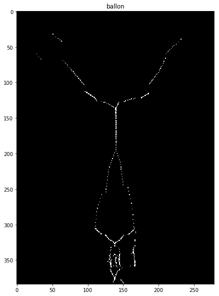

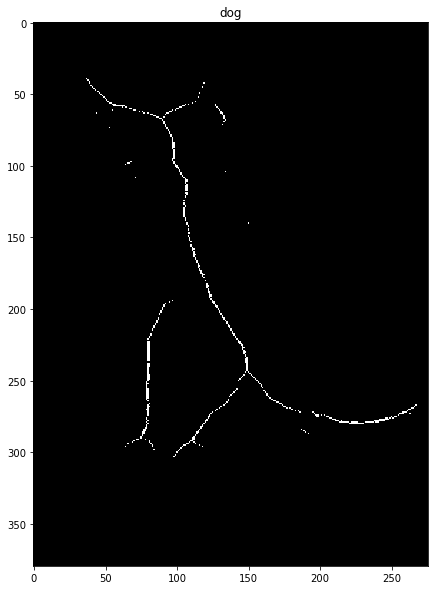

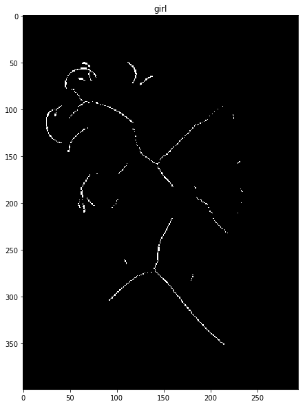

```python
img10 = cv2.imread("HotBallon.png" , cv2.IMREAD_GRAYSCALE)
img9 = cv2.imread("Dog.png" , cv2.IMREAD_GRAYSCALE)
img8 = cv2.imread("Girl.png" , cv2.IMREAD_GRAYSCALE)


imgArray = [img10 , img9 , img8]
namesArray=["ballon" , "dog" , "girl" ]
i=0
for img in imgArray:
    size = np.size(img)
    skel = np.zeros(img.shape ,np.uint8)

    ret,img = cv2.threshold(img,127,255,0)
    img = 255-img
    #plt.title('aaaaaaaaaaaaaaaaaaa'),plt.imshow(img,cmap='gray')

    element = cv2.getStructuringElement(cv2.MORPH_CROSS,(3,3))
    done = False
    while (not done):
        eroded = cv2.erode(img,element)
        temp = cv2.dilate(eroded,element)
        temp = cv2.subtract(img , temp)
        skel = cv2.bitwise_or(skel ,temp)
        img = eroded.copy()
        zeros = size - cv2.countNonZero(img)
        if zeros == size:
            done = True
    imgArray[i]=skel
    plt.figure(figsize=(10,10))
    plt.title(namesArray[i]),plt.imshow(skel , cmap = 'gray')
    plt.show()
    i=i+1
```

## B)

###### use the contours to compute the area and centroids of the given images

```python
i=0
for img in imgArray:
    img = 255-img
    #plt.imshow(img,cmap='gray')
    im2, contours, hierarchy = cv2.findContours(img,cv2.RETR_TREE,cv2.CHAIN_APPROX_SIMPLE)
    cnt = contours[0]
    M=cv2.moments(cnt)
    'centroid'
    cx=int(M['m10']/M['m00'])
    cy=int(M['m01']/M['m00'])
    'area'
    area = cv2.contourArea(cnt)
    print(namesArray[i]+' centroid = ' ,cx ,cy , '    area= ' ,area)
    i=i+1
```

```
ballon centroid =  139 191     area=  106474.0
dog centroid =  137 189     area=  104225.0
girl centroid =  146 199     area=  116907.0
```

# Question 9

### Hit and Miss Transform

###### use the preveous sckeletons to find out the isolated end points and the junction points of the given images

###### kernels from 1 to 16 represent diffrent types of isolated points alogside with junclions

###### simply by running successive transforms using different structuring elements, and then ORing the results together.

###### this image was then dilated once using a cross-shaped structuring element in order to mark these isolated points clearly

###### and this was then ORed with the original skeleton in order to produce the overlay.

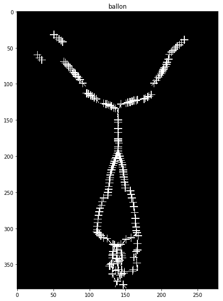

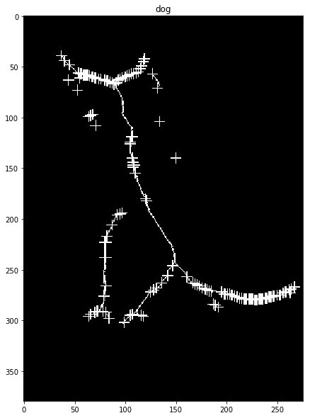

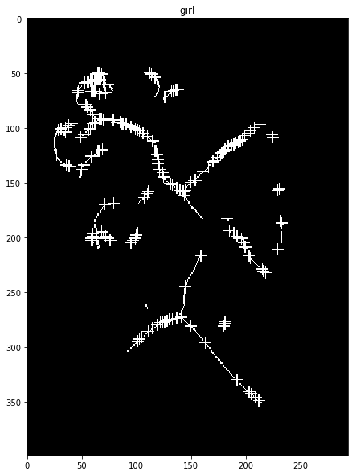

```python
#plt.imshow(imgArray[2],cmap='gray')

k1 = np.array((
[-1,-1,-1],
[0,1,0],
[0,0,0]) ,dtype ='int')

k2 = np.array((
[0,0,0],
[0,1,0],
[-1,-1,-1]) ,dtype ='int')

k3 = np.array((
[-1,0,0],
[-1,1,0],
[-1,0,0]) ,dtype ='int')

k4 = np.array((
[0,0,-1],
[0,1,-1],
[0,0,-1]) ,dtype ='int')

k5 = np.array((
[-1,1,-1],
[-1,1,-1],
[1,-1,1]) ,dtype ='int')

k6 = np.array((
[1,-1,1],
[-1,1,-1],
[-1,1,-1]) ,dtype ='int')

k7 = np.array((
[-1,-1,1],
[1,1,-1],
[-1,-1,1]) ,dtype ='int')

k8 = np.array((
[1,-1,-1],
[-1,1,1],
[1,-1,-1]) ,dtype ='int')

k9 = np.array((
[1,-1,-1],
[-1,1,-1],
[1,-1,1]) ,dtype ='int')

k10 = np.array((
[-1,-1,1],
[-1,1,-1],
[1,-1,1]) ,dtype ='int')

k11 = np.array((
[1,-1,1],
[-1,1,-1],
[1,-1,-1]) ,dtype ='int')

k12 = np.array((
[1,-1,1],
[-1,1,-1],
[-1,-1,1]) ,dtype ='int')

k13 = np.array((
[-1,1,-1],
[0,1,1],
[1,0,-1]) ,dtype ='int')

k14 = np.array((
[-1,0,1],
[1,1,0],
[-1,1,-1]) ,dtype ='int')

k15 = np.array((
[1,0,-1],
[0,1,1],
[-1,1,-1]) ,dtype ='int')

k16 = np.array((
[-1,1,-1],
[1,1,0],
[-1,0,1]) ,dtype ='int')

K = [k1,k2,k3,k4,k5,k6,k7,k8,k9,k10, k11,k12,k13,k14,k15,k16]

for j in range(len(imgArray)):
    img = imgArray[j].copy()
    img_dash= cv2.morphologyEx(img , cv2.MORPH_HITMISS,K[0])
    for i in range(len (K)):
            img = cv2.morphologyEx(img , cv2.MORPH_HITMISS,K[i])
            img_dash = cv2.bitwise_or(img,img_dash)



    img_dash=cv2.dilate(img_dash,cv2.getStructuringElement(cv2.MORPH_CROSS,(11,11)),iterations =1 )
    img_dash=cv2.bitwise_or(img_dash,imgArray[j])
    plt.figure(figsize=(10,10)) ,plt.title(namesArray[j]),plt.imshow(img_dash,cmap='gray')
    plt.show()
```

# Question 10

###### using two different algorithms to count down the chars in the image

# A)

[figure not shown]

```
Found  315 char
```

```python
 imglast = cv2.imread("words.png",cv2.IMREAD_GRAYSCALE)

#plt.imshow(imglast,cmap='gray')

img=imglast.copy()
size = np.size(img)
skel = np.zeros(img.shape ,np.uint8)

ret,img = cv2.threshold(img,127,255,0)
img = 255-img
#plt.title('aaaaaaaaaaaaaaaaaaa'),plt.imshow(img,cmap='gray')

element = cv2.getStructuringElement(cv2.MORPH_RECT,(3,3))
done = False
while (not done):
    eroded = cv2.erode(img,element)
    temp = cv2.dilate(eroded,element)
    temp = cv2.subtract(img , temp)
    skel = cv2.bitwise_or(skel ,temp)
    img = eroded.copy()
    zeros = size - cv2.countNonZero(img)
    if zeros == size:
        done = True

#imgArray[i]=skel
plt.figure(figsize=(10,10))
plt.title('skel'),plt.imshow(skel , cmap = 'gray')
plt.show()


(_, contours, _) = cv2.findContours(skel, cv2.RETR_EXTERNAL,cv2.CHAIN_APPROX_SIMPLE)
print("Found " , len(contours),'char')
```

# B)

https://mmeysenburg.github.io/image-processing/08-contours/

```python
# read image, convert to grayscale, blur, and threshold to
# make binary image
import math
def colorDistance(kCol, uCol):
    # compute sum of square of differences between each channel
    d = (kCol - uCol[0])**2 + (kCol - uCol[1])**2 + \
        (kCol - uCol[2])**2

    # square root of sum is the Euclidean distance between the
    # two colors
    return math.sqrt(d)



(t, binary) = cv2.threshold(imglast, 12, 255, cv2.THRESH_BINARY_INV)

# find contours
(_, contours, _) = cv2.findContours(binary, cv2.RETR_EXTERNAL,
    cv2.CHAIN_APPROX_SIMPLE)

# determine average length of contours
avg = 0
for c in contours:
    avg += len(c)

avg /= len(contours)

# reference colors
YELLOW =  0
GREEN = 255
BLUE = 255

# number of yellow dots
yellowCount = 0

# for each contour...
for c in contours:

    # ... only work with contours associated with actual dots
    if len(c) > avg / 2:

        # find centroid of shape
        M = cv2.moments(c)
        if not M['m00'] ==0:
            cx = int(M['m10']/M['m00'])
            cy = int(M['m01']/M['m00'])

        # find average color for 9 pixel kernel around centroid
        b = img[cy - 4 : cy + 5, cx - 4 : cx + 5]
       # g = img[cy - 4 : cy + 5, cx - 4 : cx + 5]
       # r = img[cy - 4 : cy + 5, cx - 4 : cx + 5]

        bAvg = np.mean(b)
        #gAvg = np.mean(g)
        #rAvg = np.mean(r)

        # find distances to known reference colors
        dist = []
        dist.append(colorDistance(YELLOW, (bAvg, gAvg, rAvg)))
        #dist.append(colorDistance(BLUE, (bAvg, gAvg, rAvg)))
        #dist.append(colorDistance(GREEN, (bAvg, gAvg, rAvg)))

        # which one is closest?
        minDist = min(dist)
        # if it was yellow, count the shape
        if dist.index(minDist) == 0:
            yellowCount += 1

print("char:", yellowCount)
```

```
char: 13
```